# assignment

### Plotting the clusters by density:

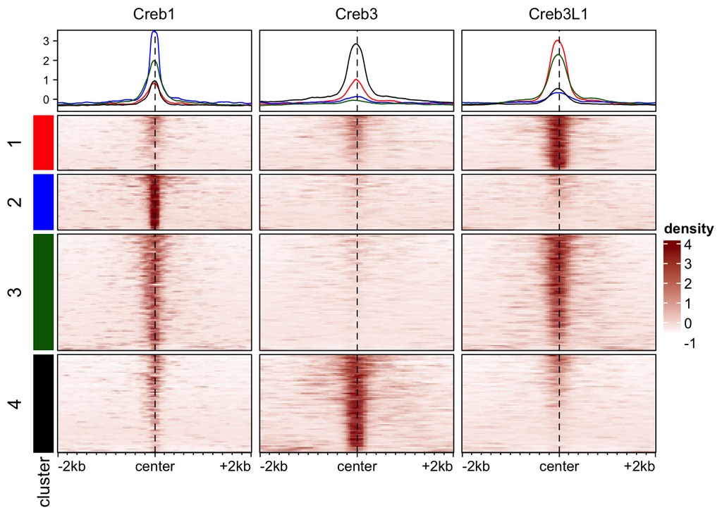

```r
mycolors <- c("1"="red", "2"="blue", "3"="darkgreen", "4"="black")
plotEnrichedHeatmaps(ese, row_split="cluster_scaled", mean_color=mycolors, colors=c("white","darkred"), scale_rows = "global")
```

### Correlation Matrix with UpSet

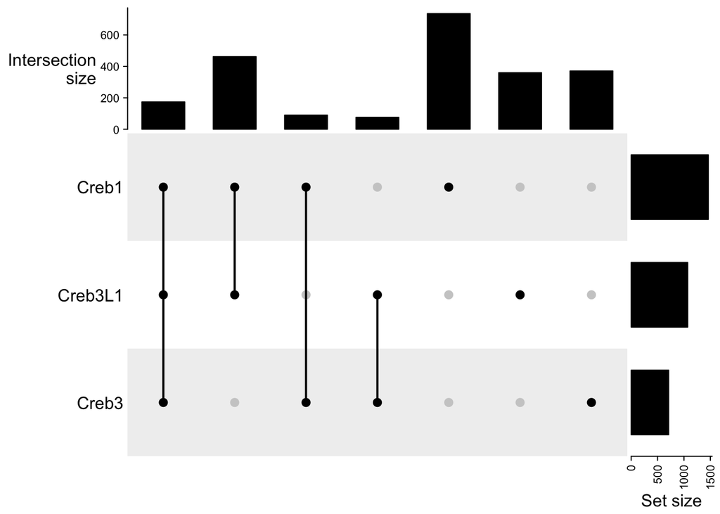

```r
m <- make_comb_mat(regionsToUpset(peaks))
UpSet(m)
```

## Enrichment analysis

### Find how many peaks belongs to transcripts with known vs unknown function

```r
# we first split the regions by cluster_scaled:
split_regions <- split(rowRanges(ese), rowData(ese)$cluster_scaled) # 383 389 813 684 - lengths(split_regions)

# Prepare the 'Known' list once (discovered transcript)
known_ensembl <- keys(org.Hs.eg.db, keytype="ENSEMBL")

analyze_peak_status <- function(cluster_gr, background_regions) {
  # Run GREAT to find annotated trasncript (function by GO:BP)
  res <- great(cluster_gr, gene_sets = "GO:BP", tss_source = "Gencode_v19", background = background_regions)
  # Get Associations
  assoc <- getRegionGeneAssociations(res)
  # Classify
  classification <- sapply(assoc$annotated_genes, function(g) {
    if (length(g) == 0) return("No Gene Assigned")
    clean_g <- gsub("\\..*$", "", g)
    if (any(clean_g %in% known_ensembl)) return("Known")
    return("Unknown")
  })
  # Return the summary table
  return(table(classification))
}

# This runs the function for each element in split_regions list (1 through 4)
all_cluster_results <- lapply(split_regions, function(x) {
  analyze_peak_status(x, regions)
})
```

[output not shown]

[output not shown]

[output not shown]

[output not shown]

[output not shown]

[output not shown]

[output not shown]

[output not shown]

[output not shown]

[output not shown]

[output not shown]

[output not shown]

[output not shown]

[output not shown]

[output not shown]

[output not shown]

[output not shown]

[output not shown]

[output not shown]

[output not shown]

[output not shown]

[output not shown]

[output not shown]

[output not shown]

[output not shown]

[output not shown]

[output not shown]

[output not shown]

[output not shown]

[output not shown]

[output not shown]

[output not shown]

[output not shown]

[output not shown]

[output not shown]

[output not shown]

[output not shown]

[output not shown]

[output not shown]

[output not shown]

[output not shown]

[output not shown]

[output not shown]

[output not shown]

[output not shown]

[output not shown]

[output not shown]

[output not shown]

[output not shown]

[output not shown]

[output not shown]

[output not shown]

[output not shown]

[output not shown]

[output not shown]

[output not shown]

[output not shown]

[output not shown]

[output not shown]

[output not shown]

[output not shown]

[output not shown]

[output not shown]

[output not shown]

[output not shown]

[output not shown]

[output not shown]

[output not shown]

[output not shown]

[output not shown]

[output not shown]

[output not shown]

```r
names(all_cluster_results) <- paste0("Cluster_", names(split_regions))

print(all_cluster_results)
```

```
## $Cluster_1
## classification
##   Known Unknown
##     373       6
##
## $Cluster_2
## classification
##   Known Unknown
##     374       8
##
## $Cluster_3
## classification
##   Known Unknown
##     792      16
##
## $Cluster_4
## classification
##   Known Unknown
##     667       8
```

### Correlation of GO between clusters

```r
# Process every cluster, extract tables, and bind into one master dataframe
results_all <- lapply(names(split_regions), function(cl_name) {
  res <- great(split_regions[[cl_name]],
               gene_sets = "GO:BP", # MF and CC has been tested too
               tss_source = "Gencode_v19",
               background = regions,
               cores = 2)
  getEnrichmentTables(res) %>%
    mutate(cluster = cl_name)
}) %>% bind_rows()
```

[output not shown]

[output not shown]

[output not shown]

[output not shown]

[output not shown]

[output not shown]

[output not shown]

[output not shown]

[output not shown]

[output not shown]

[output not shown]

[output not shown]

[output not shown]

[output not shown]

[output not shown]

[output not shown]

[output not shown]

[output not shown]

[output not shown]

[output not shown]

[output not shown]

[output not shown]

[output not shown]

[output not shown]

[output not shown]

[output not shown]

[output not shown]

[output not shown]

[output not shown]

[output not shown]

[output not shown]

[output not shown]

[output not shown]

[output not shown]

[output not shown]

[output not shown]

[output not shown]

[output not shown]

[output not shown]

[output not shown]

[output not shown]

[output not shown]

[output not shown]

[output not shown]

[output not shown]

[output not shown]

[output not shown]

[output not shown]

[output not shown]

[output not shown]

[output not shown]

[output not shown]

[output not shown]

[output not shown]

[output not shown]

[output not shown]

[output not shown]

[output not shown]

[output not shown]

[output not shown]

[output not shown]

[output not shown]

[output not shown]

[output not shown]

[output not shown]

[output not shown]

[output not shown]

[output not shown]

[output not shown]

[output not shown]

[output not shown]

[output not shown]

```r
# Keep only terms where raw p-value < 0.05
sig_results <- results_all %>% filter(p_value < 0.05)

# Create a list of IDs for each cluster
id_list <- split(sig_results$id, sig_results$cluster)
all_unique_ids <- unique(sig_results$id)

# Create the binary membership matrix (Rows = GO IDs, Cols = Clusters)
membership <- do.call(cbind, lapply(id_list, function(x) all_unique_ids %in% x))
colnames(membership) <- names(id_list)

# Generate the Intersection Counts (How many terms overlap)
overlap_counts <- t(membership) %*% membership

print("--- GO Terms MATRIX (p_value < 0.05) ---")
```

```
## [1] "--- GO Terms MATRIX (p_value < 0.05) ---"
```

```r
print(overlap_counts)
```

```
##    1   2  3   4
## 1 42   0  0   0
## 2  0 132  0   2
## 3  0   0 83   0
## 4  0   2  0 229
```

```r
# Filter for significant terms (e.g., p_adjust < 0.05)
sig_counts <- results_all[results_all$p_adjust < 0.05, ]

# Print the count per cluster
print("--- GO Terms (p_adjust < 0.05) ---")
```

```
## [1] "--- GO Terms (p_adjust < 0.05) ---"
```

```r
table(sig_counts$cluster)
```

```
##
## 2
## 2
```

## Discussion

#### Are the GO terms found for each cluster statistically enriched compared to all region (whole regions from the experiment, not the entire genome) ? The confidence: almost no GO terms have p_adj < 0.05 but only p_value < 0.05.

## Conclusion

### Different combination of Creb proteins are correlated with different biological functions.

### P.S. What to do next: watch each cluster GO terms and see which biological functions are correlated to the corresponding combination of Creb proteins. I didn’t do that.